# Modeling

Building upon the insights gained from the Exploratory Data Analysis (EDA) and Data Preparation stages, we embark on the modeling phase to unravel the factors influencing user activity on the Discovery tab. In this context, the term "active" denotes user interaction with a recommended card, specifically through a click. Consequently, the output variable (Y) is the binary **isClick** variable extracted from the final impressions dataset.

Our modeling strategy involves exploring two distinct categories of machine learning models: sophisticated 'black-box' models and robust, classic interpretable models. The former category encompasses Neural Networks, chosen as a benchmark for its prowess in handling classification problems and capturing intricate relationships in high-dimensional spaces. Meanwhile, the latter category includes regularized logistic regression, decision trees, and ensembled decision trees. These models are selected for their interpretability and effectiveness in conveying insights to the NCM management team.

The overarching goal is to establish the infrastructure for a recommendation system that tailors and prioritizes card recommendations based on the user's likelihood to click on a given card.

For each model, we initiate a grid search to fine-tune hyperparameters. This involves employing a 5-fold cross-validation setup, which allows us to identify optimal parameters by evaluating their performance across different validation sets.

### Import Libraries

```python
import warnings
warnings.filterwarnings('ignore')

import pandas as pd
import numpy as np
import matplotlib.pyplot as plt
import plotly.express as px
import seaborn as sns
import pyarrow.parquet as pq
import pyarrow as pa
from imblearn.over_sampling import RandomOverSampler
from sklearn.preprocessing import OneHotEncoder, StandardScaler
from sklearn.utils import shuffle
from sklearn.model_selection import train_test_split, RandomizedSearchCV
from sklearn.compose import ColumnTransformer
from sklearn.pipeline import Pipeline
from sklearn.model_selection import ParameterGrid
from sklearn.model_selection import KFold
from sklearn.model_selection import GridSearchCV
from sklearn.model_selection import StratifiedKFold
from sklearn.metrics import roc_curve, auc, accuracy_score, confusion_matrix, classification_report, roc_auc_score
from sklearn.tree import DecisionTreeClassifier, plot_tree
from sklearn.ensemble import RandomForestClassifier
from sklearn.linear_model import LogisticRegression
import statsmodels.api as sm
from keras.models import Sequential
from keras.layers import Dense
from keras.optimizers import SGD
from keras.callbacks import EarlyStopping
```

```
WARNING:tensorflow:From C:\Users\Noha\AppData\Roaming\Python\Python39\site-packages\keras\src\losses.py:2976: The name tf.losses.sparse_softmax_cross_entropy is deprecated. Please use tf.compat.v1.losses.sparse_softmax_cross_entropy instead.
```

### Reusable functions

```python
# Defining reusable functions

def roc_auc_curve(y_pred_prob, title, threshold = 0.5):
    # Convert probabilities predictions to binary (0 or 1) based on a threshold
    y_pred_class = (y_pred_prob > threshold).astype(int)

    # Calculate ROC curve
    fpr, tpr, thresholds = roc_curve(y_test, y_pred_prob)
    roc_auc = auc(fpr, tpr)

    # Plot ROC curve
    plt.figure(figsize=(10, 7))
    plt.plot(fpr, tpr, color='darkorange', lw=2, label='ROC curve (area = {:.2f})'.format(roc_auc))
    plt.plot([0, 1], [0, 1], color='navy', lw=2, linestyle='--')
    plt.xlabel('False Positive Rate')
    plt.ylabel('True Positive Rate')
    plt.title(title)
    plt.legend(loc="lower right")
    plt.show()

def cm_print(X_test, y_test, model, title='Confusion Matrix on Test Data'):
    # Print confusion matrix, given the X_test, y_test and the model
    cm = confusion_matrix(y_test, model.predict(X_test))
    plt.figure(figsize=(6, 6))
    sns.heatmap(cm, annot=True, fmt="d", cmap="Blues", xticklabels=['Predicted 0', 'Predicted 1'],
                yticklabels=['Actual 0', 'Actual 1'])
    plt.xlabel('Predicted Label')
    plt.ylabel('True Label')
    plt.title(title)
    plt.show()
```

### Importing Data

We import the database that was created in the EDA and Data Preparation script.

```python
impressions_final = pd.read_parquet('./data_treated/impressions_user_card_content.parquet')
```

## Pre-Modelling Setup

### Take Random Sample of Data

The intricate nature of processing and modeling the complete impressions dataset poses challenges for personal laptops to handle due to computational complexity. Consequently, a strategic choice has been made to extract a random sub-sample comprising 5 million impressions. This sub-sample will be utilized for subsequent analyses. To ensure its representativeness, a comparison of summary statistics between the original dataset and the sub-sample will be conducted. This approach aims to strike a balance between computational feasibility and maintaining data integrity for meaningful analysis.

```python
sample_size = 5000000

impressions_sample =  impressions_final.sample(n=sample_size, random_state=42)  # Use a fixed seed for reproducibility
```

```python
# Extract the statistics for each dataset
stats_full = impressions_final.describe(include='all').transpose()[['mean', 'std', 'top']]
stats_sample = impressions_sample.describe(include='all').transpose()[['mean', 'std', 'top']]

# Merge the two stats dataframes on the common index
merged_stats = pd.merge(stats_full, stats_sample, left_index=True, right_index=True, suffixes=('_full', '_sample'))

# Display the statistics comparison
merged_stats.fillna('-').sort_index(axis=1, level=0)
```

|  | mean_full | mean_sample | std_full | std_sample | top_full | top_sample |
| --- | --- | --- | --- | --- | --- | --- |
| dt | 15.448434 | 15.440991 | 8.641026 | 8.641392 | - | - |
| impressPosition | 28.823878 | 28.907017 | 163.423465 | 165.171837 | - | - |
| isClick | 0.049703 | 0.049829 | 0.217332 | 0.217592 | - | - |
| mlogId | - | - | - | - | NCOCOCPCICICJC | NCOCOCPCICICJC |
| userId | - | - | - | - | PCLCKCOCKCHCGCHCICMC | PCLCKCOCKCHCGCHCICMC |
| impressTime_wday | - | - | - | - | Saturday | Saturday |
| impressTime_dhour | 9.949675 | 9.949374 | 5.674839 | 5.673895 | - | - |
| prior_user_probClick | 0.019118 | 0.019119 | 0.047683 | 0.047648 | - | - |
| prior_user_probLike | 0.000988 | 0.000982 | 0.007255 | 0.00718 | - | - |
| prior_user_probShare | 0.000158 | 0.000156 | 0.002731 | 0.00268 | - | - |
| prior_user_probComment | 0.000081 | 0.000081 | 0.001818 | 0.001808 | - | - |
| prior_user_probSwipe | 0.005583 | 0.005587 | 0.020369 | 0.02038 | - | - |
| prior_user_probCheckCreator | 0.000245 | 0.000244 | 0.002651 | 0.002632 | - | - |
| prior_user_avgViewDuration | 0.461817 | 0.461761 | 1.36224 | 1.359518 | - | - |
| prior_card_probClick | 0.065101 | 0.06509 | 0.107207 | 0.106964 | - | - |
| prior_card_probLike | 0.011495 | 0.011444 | 0.088412 | 0.088121 | - | - |
| user_province | - | - | - | - | guangdong | guangdong |
| user_age | 21.334879 | 21.333797 | 2.947511 | 2.947714 | - | - |
| user_gender | - | - | - | - | unknown | unknown |
| user_tenure | 25.024074 | 25.025695 | 14.976474 | 14.972009 | - | - |
| user_is_creator | 0.035733 | 0.03574 | 0.185624 | 0.18564 | - | - |
| publishTime | 75.163229 | 75.149732 | 50.616119 | 50.596526 | - | - |
| type | 1.425609 | 1.42558 | 0.494435 | 0.494431 | - | - |
| contentId | - | - | - | - | unknown | unknown |
| talkId | 698969.89084 | 699294.49459 | 561733.064873 | 561698.090217 | - | - |
| creator_gender | - | - | - | - | unknown | unknown |
| creator_tenure | 31.602638 | 31.605891 | 15.046385 | 15.055426 | - | - |
| creator_level | 7.376663 | 7.376282 | 1.813961 | 1.814721 | - | - |
| creator_logFollows | 3.297672 | 3.298094 | 1.515768 | 1.515604 | - | - |
| creator_logFolloweds | 6.840848 | 6.841388 | 2.487949 | 2.487119 | - | - |
| impression_count | 1.0 | 1.0 | 0.0 | 0.0 | - | - |
| past_pref_artist_probClick | 0.011332 | 0.011336 | 0.057454 | 0.057474 | - | - |
| past_pref_song_probClick | 0.010006 | 0.009998 | 0.054133 | 0.05408 | - | - |
| past_pref_creator_probClick | 0.003732 | 0.003711 | 0.052935 | 0.052858 | - | - |

After confirming that our sample is still representative of the entire dataset based on the analysis of the statistics, we delete the original dataset to preserve memory.

```python
# Deleting original dataset
del impressions_final
```

### Define X and y

```python
X = impressions_sample.drop(['isClick'], axis= 1)
y = impressions_sample['isClick']
```

```python
del impressions_sample
```

### Grouping of Categorical Variables

Some categorical variables in the dataset exhibit a large number of distinct categories, and a considerable portion of these categories have relatively low occurrences in the data. This situation can introduce unwanted noise to machine learning models and present computational challenges due to the increased complexity associated with a high number of categories. To address this issue, a common strategy is to condense or group together all categories that represent less than a threshold % of the total sample data. This helps streamline the categorical variables, making them more manageable for analysis and modeling, while also improving the efficiency and performance of the machine learning algorithms. The threshold was chosen to be 0.5% threshold, representing 25k entries.

```python
threshold =  0.005
round(threshold*X.shape[0],0)
```

```
25000.0
```

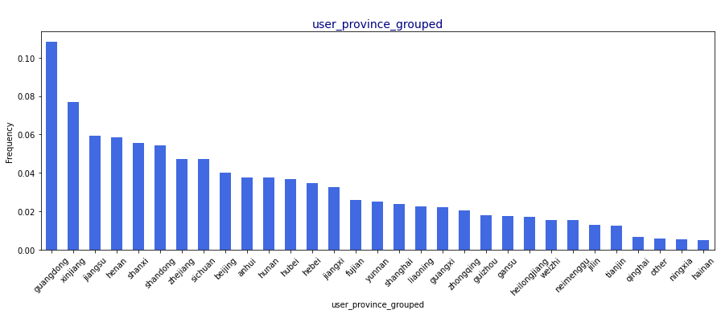

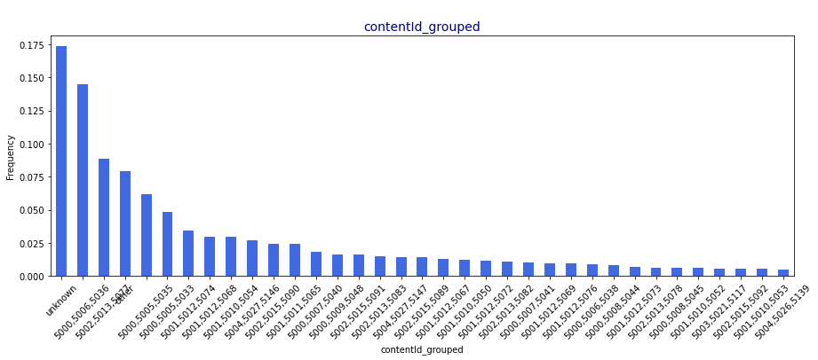

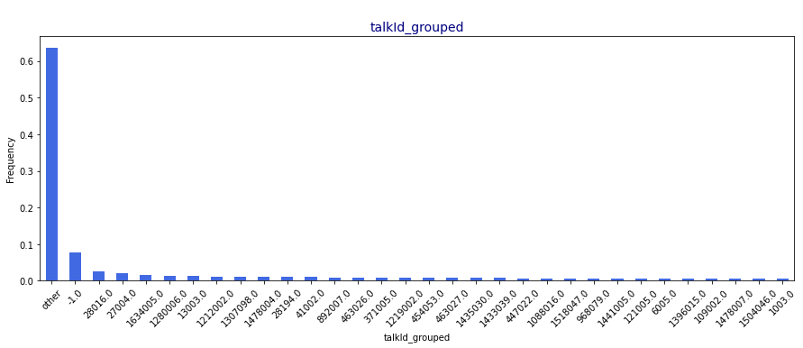

```python
# Define function to plot bar chart
def plot_bar(data, column):
    plt.figure(figsize=(15, 5))
    data[column].value_counts(normalize=True).sort_values(ascending=False).plot(kind='bar', color='royalblue')
    plt.title('\n'+column, color='navy', size=14)
    plt.xlabel(column)
    plt.xticks(rotation=45)
    plt.ylabel('Frequency')
    plt.show()


# Define function to group categorical data
def group_categorical(data, column, threshold):
    frequency = data[column].value_counts(normalize=True)
    if frequency[frequency<threshold].shape[0]>0:
        grouped_column = column + '_grouped'
        data[grouped_column] = np.where(data[column].map(frequency) < threshold, 'other', data[column])
        plot_bar(data, column+'_grouped')


categorical_cols = ['type', 'user_gender', 'creator_gender', 'impressTime_wday',
                     'user_province', 'contentId', 'talkId']

# Transform the categorical variables
for column in categorical_cols:
    group_categorical(X, column, threshold)
```

```python
grouped_columns = [col.replace('_grouped', '') for col in X.columns if col.endswith("_grouped")]
X.drop(grouped_columns, axis=1, inplace = True)
```

### One-Hot Encoding of Categorical Variables

```python
# Identify categorical columns
categorical_cols = ['type', 'user_gender', 'creator_gender', 'impressTime_wday',
                     'user_province_grouped', 'contentId_grouped', 'talkId_grouped']

# Identify numerical columns
other_cols = [col for col in X.columns if col not in categorical_cols]

numerical_cols = other_cols.copy()

for feature in ['userId', 'dt', 'impression_count', 'mlogId']:
    numerical_cols.remove(feature)
```

```python
# One-hot encode categorical columns
encoder = OneHotEncoder(drop='first', sparse=False)
X_encoded_cat_all = pd.DataFrame()

for column in categorical_cols:
    X_encoded_cat = encoder.fit_transform(X[[column]])
    X_encoded_cat_df = pd.DataFrame(X_encoded_cat, columns=encoder.get_feature_names_out([column]))
    X_encoded_cat_all = pd.concat([X_encoded_cat_all, X_encoded_cat_df], axis=1)
    print(X_encoded_cat_all.shape)

# Concatenate one-hot encoded features with numerical features
X_encoded =pd.concat([X_encoded_cat_all.reset_index(drop=True), X[other_cols].reset_index(drop=True)], axis=1)
```

```
(5000000, 1)
(5000000, 3)
(5000000, 5)
(5000000, 11)
(5000000, 41)
(5000000, 75)
(5000000, 106)
```

**Save X_encoded datasets**

```python
pq.write_table(pa.Table.from_pandas(X_encoded), './data_treated/X_encoded.parquet')
pq.write_table(pa.Table.from_pandas(pd.DataFrame({'isClick': y}).reset_index()), './data_treated/y.parquet')
```

```python
#drop un-needed columns
X_encoded.drop(['userId', 'dt', 'impression_count', 'mlogId'], axis= 1,inplace= True)
X_encoded.shape
```

```
(5000000, 128)
```

### Train-Test Split

Here we perform the splitting of the dataset into training and testing. We do not separate a validation set, since we will use cross-validation approaches for the hyper-parameter tuning

```python
# Splitting the data into training and test sets with a 30% split
X_train, X_test, y_train, y_test = train_test_split(X_encoded, y, test_size=0.30, random_state=42)
```

```python
# Dropping the indexes
X_train.reset_index(inplace=True, drop=True)
X_test.reset_index(inplace=True, drop=True)
y_train.reset_index(inplace=True, drop=True)
y_test.reset_index(inplace=True, drop=True)
```

```python
# To preserve memory, we delete the original datasets
del X_encoded, X, y
```

### Balancing the Data

As seen in the previous section, the minority class of isClick (where isClick=1) constitutes less than 5% of the dataset. This imbalance raises concerns as machine learning models tend to be biased towards the majority class when faced with such scenarios, resulting in suboptimal performance for the minority class. In other words, the model may not effectively learn patterns associated with the minority class due to its limited representation in the training data. To address this issue and ensure the model's ability to generalize well across both classes, we employ oversampling techniques on the minority class in the training dataset. This involves artificially increasing the instances of the minority class through duplication, promoting a more balanced and representative training set.

Additionally, we will explore the re-weighting approach, an inherent functionality in various model functions, to further address data imbalance.

```python
np.random.seed(42)

oversample_rate = 6

ind_train_1 = np.where(y_train == 1)[0]
ind_train_1_new = np.random.choice(ind_train_1, oversample_rate * len(ind_train_1), replace=True)
ind_train_0 = np.where(y_train == 0)[0]

X_train_resampled = X_train.iloc[np.concatenate((ind_train_1_new, ind_train_0)), :]
y_train_resampled = y_train.iloc[np.concatenate((ind_train_1_new, ind_train_0))]

X_train_resampled, y_train_resampled = shuffle(X_train_resampled, y_train_resampled, random_state=42)
```

```python
# Check the shape after oversampling
print(X_train_resampled.shape)
print(y_train_resampled.shape)
```

```
(4374010, 128)
(4374010,)
```

```python
# Check the class distribution after oversampling
print(np.mean(y_train_resampled))
```

```
0.23978271654614416
```

**Save train and test datasets**

```python
pq.write_table(pa.Table.from_pandas(X_train), './data_treated/X_train.parquet')
pq.write_table(pa.Table.from_pandas(X_train_resampled), './data_treated/X_train_resampled.parquet')
pq.write_table(pa.Table.from_pandas(pd.DataFrame({'isClick': y_train})), './data_treated/y_train.parquet')
pq.write_table(pa.Table.from_pandas(pd.DataFrame({'isClick': y_train_resampled})), './data_treated/y_train_resampled.parquet')
pq.write_table(pa.Table.from_pandas(X_test), './data_treated/X_test.parquet')
pq.write_table(pa.Table.from_pandas(pd.DataFrame({'isClick': y_test})), './data_treated/y_test.parquet')
```

**Exclude some features**

In this section, it is noted that despite being placed before the model fitting phase, it was born out of observations made during test runs of the decision tree. The findings indicated that the model identified impression position, the card's prior click probability, and the user's prior click-through rate as the most influential features. However, upon reflection, it was concluded that these features are closely tied to and influenced by the existing recommendation system.

As a result, the decision was made to exclude these features from the analysis. The intention behind this exclusion is to allow for a focused examination of the actual impact of user and content demographics on the user's activity level, unencumbered by the intertwined effects of the recommendation system.

```python
features =['impressPosition', 'prior_user_probClick', 'prior_card_probClick']

X_train_no_probs = X_train.drop(features, axis = 1)
X_train_resampled_no_probs = X_train_resampled.drop(features, axis = 1)
X_test_no_probs = X_test.drop(features, axis = 1)


numerical_cols_no_probs = numerical_cols.copy()
for feature in features:
    numerical_cols_no_probs.remove(feature)
```

### Normalisation of Numerical Variables

```python
# Create a column transformer numerical scaling
preprocessor = ColumnTransformer(
    transformers=[
        ('num', StandardScaler(), numerical_cols)
    ],
    remainder='passthrough'
)



preprocessor_no_probs = ColumnTransformer(
    transformers=[
        ('num', StandardScaler(), numerical_cols_no_probs)
    ],
    remainder='passthrough'
)
```

## Machine Learning Models

#### We start the modeling process by the **sophisticated 'black-box' models**, namely Neural Network.

### Benchmark - Neural Network

### Balancing Technique: Oversampling

For computational efficiency purposes, a dedicated notebook has been established for executing the hyperparameter tuning script, titled **'Neural Network Hyperparameter Tuning - Resampling'** and submitted within the zipfolder. This notebook relies on the training dataset where the minority class in the output variable was **oversmapled**. Quoting from that specific notebook:

*We delve into an investigation of hyperparameters to enhance the efficiency of a neural network. The hyperparameters under consideration include the number of training epochs, batch size, hidden layer count, and the quantity of neurons within each layer. We specifically limit the exploration of layer counts to 1, 2, and 3, while varying the number of neurons per layer across 5, 10, and 15. The rationale behind constraining the layer and neuron count lies in recognizing the inherent simplicity of the input features. As most of the input features are binary variables derived from categorical variables through one-hot encoding, a sophisticated neural network architecture is deemed unnecessary. Consequently, our focus remains on a selection of modest architectures to strike a balance between model expressiveness and computational efficiency.*

*Utilizing a grid search methodology, we systematically assess the neural network's performance across diverse combinations of hyperparameter values. This approach allows us to pinpoint the hyperparameter set that demonstrates optimal performance on the validation sets within a k-fold cross-validation framework.*

*Our evaluation of hyperparameter sets revolves around two performance metrics: accuracy and the area under the receiver operating characteristic curve (AUC). These metrics provide a comprehensive insight into the model's proficiency in accurately classifying observations, within both majority and minority classes.*

*Following the completion of the grid search, our primary aim is to identify the hyperparameter set exhibiting the highest accuracy and AUC on the validation sets within the k-fold cross-validation. This best-performing hyperparameter set will subsequently serve as the base for the final model configuration, embodying a compromise between computational efficiency and predictive accuracy."*

The code set was inspired by the class work and the following online article: https://www.analyticsvidhya.com/blog/2021/05/tuning-the-hyperparameters-and-layers-of-neural-network-deep-learning/

**Import the best performing parameters**

The best performing set of parameters was defined in the **'Neural Network Hyperparameter Tuning - Resampling'** notebook on the following basis:

*When we compare the top two sets of hyperparameters—one optimized for accuracy and the other for AUC—we observe a minimal difference in accuracy, just 0.019%. However, the distinction becomes more apparent when we examine AUC. There is a significant gap in both the average AUC and the consistency across the 5 validation folds, as indicated by the higher standard deviation of 6.445 in the best-Accuracy model compared to 0.394 in the best-AUC model. This leads us to favor the model with the highest AUC. Opting for this model provides a substantial improvement in AUC, ensuring more robust performance across various validations. The slight compromise in overall accuracy is overshadowed by the considerable gains in AUC and the heightened confidence in the model's performance.*

```python
import pickle

# Load the best performance NN parameters dictionary from the file
with open('./models/best_params_NN_resampled.pkl', 'rb') as file:
    loaded_NN_params = pickle.load(file)

# print the parameters
print(loaded_NN_params)
```

```
{'batch_size': 100000, 'epochs': 60, 'layers': 2, 'learning_rate': 0.01, 'neurons': 15}
```

**Run and Save Optimal NN Model**

```python
# Function to plot diagnostic learning curves
def summarize_diagnostics(history):
    plt.figure(figsize=(17, 4))

    plt.subplot(131)
    plt.title('Cross Entropy Loss')
    plt.plot(history.history['loss'], color='royalblue', label='train')

    plt.subplot(132)
    plt.title('Classification Accuracy')
    plt.plot(history.history['accuracy'], color='royalblue', label='train')

    plt.subplot(133)
    plt.title('Classification AUC')
    plt.plot(history.history['auc'], color='royalblue', label='train')
    plt.show()
```

```python
# define the nn model
model = Sequential()

# add input and first hidden layer
model.add(Dense(loaded_NN_params['neurons'], input_shape=(X_train_resampled_no_probs.shape[1],),
                activation='relu', kernel_initializer='he_uniform'))

# add other hidden layers
for _ in range(loaded_NN_params['layers'] - 1):
    model.add(Dense(loaded_NN_params['neurons'], activation='relu', kernel_initializer='he_uniform'))

# add output layer
model.add(Dense(1, activation='sigmoid'))  # Output - binary

# setup optimisation
opt = SGD(learning_rate=loaded_NN_params['learning_rate'], momentum=0.9)

# compile model
model.compile(optimizer=opt, loss='binary_crossentropy', metrics=['accuracy', 'AUC'])

# fit model
history = model.fit(X_train_resampled_no_probs, y_train_resampled, epochs= loaded_NN_params['epochs'],
                    batch_size= loaded_NN_params['batch_size'],  verbose=0)
```

[output not shown]

**Performance on Training Data**

```
NN Train Loss (binary cross entropy): 53.212
NN Train AUC: 62.55
NN Train Accuracy: 76.022
```

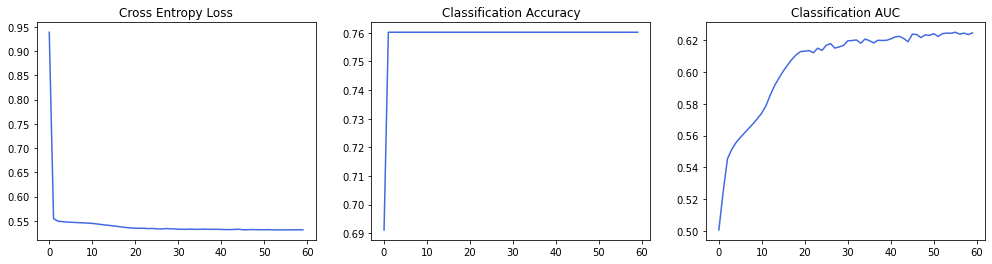

```python
# evaluate model performance on train data
loss, acc, auc = model.evaluate(X_train_resampled_no_probs, y_train_resampled, verbose=0)
y_pred_proba = model.predict(X_train_resampled_no_probs, verbose=0)
auc = roc_auc_score(y_train_resampled, y_pred_proba)


print(f'NN Train Loss (binary cross entropy): {round(loss * 100, 3)}')
print(f'NN Train AUC: {round(auc * 100, 3)}')
print(f'NN Train Accuracy: {round(acc * 100, 3)}')


summarize_diagnostics(history)
```

**Save Optimal NN Model**

```python
model.save('./models/optimal_NN_resampled.keras')

with open('./models/optimal_NN_callback_resampled.pkl', 'wb') as file:
    pickle.dump(history.history, file)
```

**Evaluate Optimal Neural Network on Test Dataset**

```python
loss, acc, auc = model.evaluate(X_test_no_probs, y_test, verbose=0)
y_pred_proba = model.predict(X_test_no_probs, verbose=0)
auc = roc_auc_score(y_test, y_pred_proba)


print(f'NN Test Loss (binary cross entropy): {round(loss * 100, 3)}')
print(f'NN Test Accuracy: {round(acc * 100, 3)}')
print(f'NN Test AUC: {round(auc * 100, 3)}')
```

```
NN Test Loss (binary cross entropy): 30.185
NN Test Accuracy: 95.044
NN Test AUC: 62.632
```

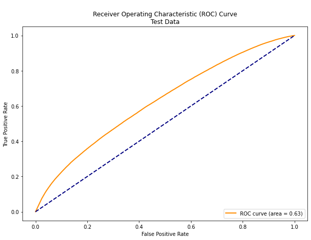

```python
threshold =  0.5
roc_auc_curve(y_pred_proba, y_test, title = "\nReceiver Operating Characteristic (ROC) Curve\nTest Data", threshold = threshold)
```

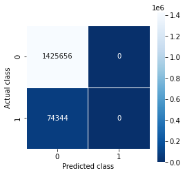

```python
y_pred= (y_pred_proba > threshold).astype(int)

cm = confusion_matrix(y_test,y_pred)
plt.figure(figsize=(4,4))
sns.heatmap(cm, annot=True, fmt=".0f", linewidths=.5, square = True, cmap = 'Blues_r')
plt.ylabel('Actual class')
plt.xlabel('Predicted class')
plt.show()
```

**Conclusion**: Despite the initial promise suggested by high accuracy and a favorable area under the ROC curve, a deeper analysis of the confusion matrix on the test data uncovers a significant issue. The model exhibits a complete inability to accurately predict instances of the "positive" class, where isClick equals 1. Instead, it uniformly assigns all instances to the majority class (isClick equals 0).

We suspect that the choice of the oversampling technique may have negatively impacted the model's ability to discern underlying patterns. Consequently, the subsequent model iteration involves replacing the oversampling technique with re-weighting. This adjustment aims to reassess the neural network's performance, providing it with another opportunity to demonstrate effectiveness.

### Benchmark - Neural Network

### Balancing Technique: Reweighting

**Import the best performing parameters**

The best performing set of parameters was defined in the **'Neural Network Hyperparameter Tuning - Reweighing'** notebook on the following basis:

The results are very similar to what we've seen in the Neural Network parameter tuning using the oversampling technique for balancing the data. When we compare the top two sets of hyperparameters—one optimized for accuracy and the other for AUC—we observe a minimal difference in accuracy, just 0.001%. However, the distinction becomes more apparent when we examine AUC. There is a more significant gap in both the average AUC and the consistency across the 5 validation folds, as indicated by the higher standard deviation of 1.15 in the best-Accuracy model compared to 0.202 in the best-AUC model. This leads us to favor the model with the highest AUC. Opting for this model provides a substantial improvement in AUC, ensuring more robust performance across various validations. The slight compromise in overall accuracy is overshadowed by the considerable gains in AUC and the heightened confidence in the model's performance.

```python
import pickle

# Load the best performance NN parameters dictionary from the file
with open('./models/best_params_NN_reweighing.pkl', 'rb') as file:
    loaded_NN_params = pickle.load(file)

# print the parameters
print(loaded_NN_params)
```

```
{'batch_size': 100000, 'epochs': 80, 'layers': 1, 'learning_rate': 0.01, 'neurons': 15}
```

```python
# define the nn model
model = Sequential()

# add input and first hidden layer
model.add(Dense(loaded_NN_params['neurons'], input_shape=(X_train_no_probs.shape[1],),
                activation='relu', kernel_initializer='he_uniform'))

# add other hidden layers
for _ in range(loaded_NN_params['layers'] - 1):
    model.add(Dense(loaded_NN_params['neurons'], activation='relu', kernel_initializer='he_uniform'))

# add output layer
model.add(Dense(1, activation='sigmoid'))  # Output - binary

# setup optimisation
opt = SGD(learning_rate=loaded_NN_params['learning_rate'], momentum=0.9)

# compile model
model.compile(optimizer=opt, loss='binary_crossentropy', weighted_metrics=['accuracy', 'AUC'])

# fit model
history = model.fit(X_train_no_probs, y_train, epochs= loaded_NN_params['epochs'],
                    batch_size= loaded_NN_params['batch_size'],  verbose=0)
```

**Performance on Training Data**

```
NN Train Loss (binary cross entropy): 19.39
NN Train AUC: 61.61
NN Train Accuracy: 95.006
```

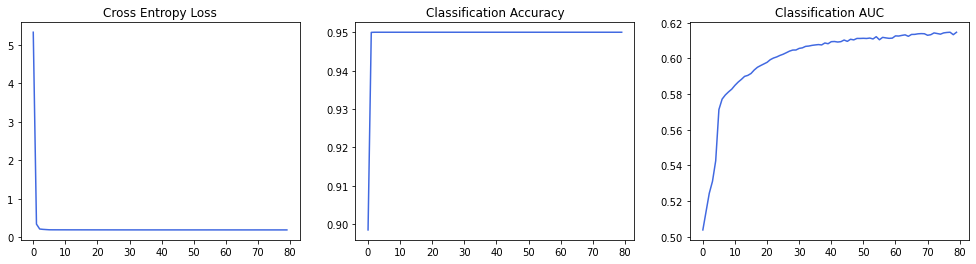

```python
# evaluate model performance on train data
loss, acc, auc = model.evaluate(X_train_no_probs, y_train, verbose=0)
y_pred_proba = model.predict(X_train_no_probs, verbose=0)
auc = roc_auc_score(y_train, y_pred_proba)


print(f'NN Train Loss (binary cross entropy): {round(loss * 100, 3)}')
print(f'NN Train AUC: {round(auc * 100, 3)}')
print(f'NN Train Accuracy: {round(acc * 100, 3)}')


summarize_diagnostics(history)
```

**Save Optimal NN Model**

```python
model.save('./models/optimal_NN_reweighing.keras')

with open('./models/optimal_NN_callback_reweighing.pkl', 'wb') as file:
    pickle.dump(history.history, file)
```

**Evaluate Optimal Neural Network on Test Dataset**

```python
loss, acc, auc = model.evaluate(X_test_no_probs, y_test, verbose=0)
y_pred_proba = model.predict(X_test_no_probs, verbose=0)
auc = roc_auc_score(y_test, y_pred_proba)


print(f'NN Test Loss (binary cross entropy): {round(loss * 100, 3)}')
print(f'NN Test Accuracy: {round(acc * 100, 3)}')
print(f'NN Test AUC: {round(auc * 100, 3)}')
```

```
NN Test Loss (binary cross entropy): 19.274
NN Test Accuracy: 95.044
NN Test AUC: 61.719
```

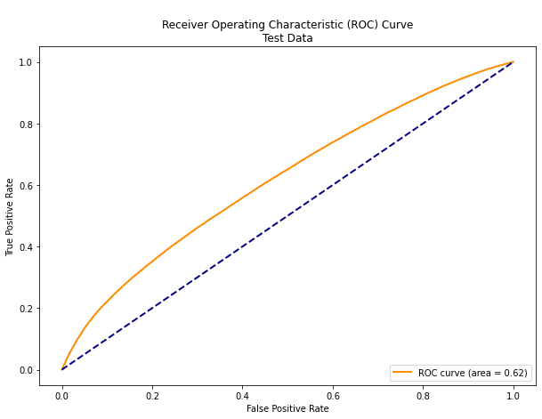

```python
threshold =  0.5
roc_auc_curve(y_pred_proba, y_test, title = "\nReceiver Operating Characteristic (ROC) Curve\nTest Data", threshold = threshold)
```

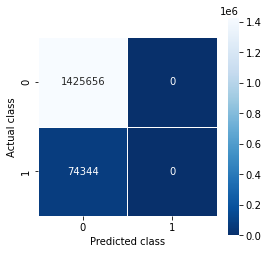

```python
y_pred= (y_pred_proba > threshold).astype(int)

cm = confusion_matrix(y_test,y_pred)
plt.figure(figsize=(4,4))
sns.heatmap(cm, annot=True, fmt=".0f", linewidths=.5, square = True, cmap = 'Blues_r')
plt.ylabel('Actual class')
plt.xlabel('Predicted class')
plt.show()
```

**Conclusion**: As seen, the performance of the neural network has not improved with the change in the balancing technique. This outcome suggests that, in this specific scenario, neural networks, despite their general flexibility and utility in diverse classification problems, prove ineffective for the given task.

#### Transitioning from neural networks, we now delve into the realm of more interpretable classic machine learning models, specifically logistic regression and decision trees. We begin with logistic regression, where our objective is to strike a balance that ensures the model's generalizability and interpretability in capturing the underlying patterns in the data. This is done by fine-tuning the regularization parameter to prevent potential overfitting scenarios.

### Regularized Logistic Regression

In the case of logistic regression, we opted for the re-weighting technique over oversampling to address data imbalance. This decision is primarly to reduce computational complexity, since the process of duplicating entries during oversampling significantly increases the sample size, thus signficantly increasing computational complexity, which we've seen while training and tuning the neural networks. Additionally, we beleive that oversampling, by its nature, might result in a loss of unique information from the original minority class samples, potentially compromising the model's ability to accurately capture the genuine underlying patterns.

Similar to the neural network parameter tuning, a separate notebook includes the script and results of the tuning process using cross-validation approach and grid-search. The best performing regularization parameter was found to be 0.03, noting that a range of np.logspace(-2, 1, 15), which includes 15 values between 0.01 and 10, was tested.

**Import the best performing parameters**

```python
import pickle

# Load the best performance LR parameters dictionary from the file
with open('./models/best_params_LR_reweighing.pkl', 'rb') as file:
    loaded_LR_params = pickle.load(file)

# print the parameters
print(loaded_LR_params)
```

```
{'logistic_regression__C': 0.02682695795279726, 'logistic_regression__max_iter': 100}
```

```python
# Create a pipeline with a preprocessor and Logistic Regression
final_pipeline = Pipeline([
    ('preprocessor', preprocessor_no_probs),
    ('logistic_regression', LogisticRegression(C=  loaded_LR_params['logistic_regression__C'], class_weight='balanced'))
])

# Fit the final model on the full training data
final_pipeline.fit(X_train_no_probs, y_train)

# Print feature importance
feature_importance = final_pipeline.named_steps['logistic_regression'].coef_[0]

# Extract the logistic regression estimator
logistic_regression_model = final_pipeline.named_steps['logistic_regression']
```

**Save the Optimal Logisitic Regression Model**

```python
from joblib import dump

model_path = './models/logistic_regression_model.joblib'

dump(logistic_regression_model, model_path)
print(f'Model saved at: {model_path}')
```

```
Model saved at: ./models/logistic_regression_model.joblib
```

```python
# Loading the best model
from joblib import load
final_pipeline = load('./models/logistic_regression_model.joblib')
```

**Performance on Training Data**

```
Accuracy Score on Full Training Data: 63.16%
```

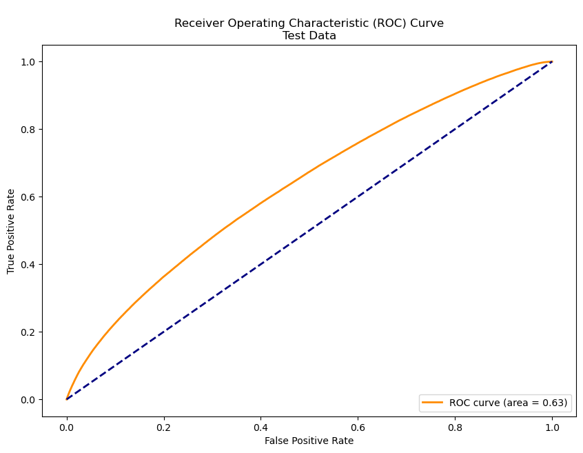

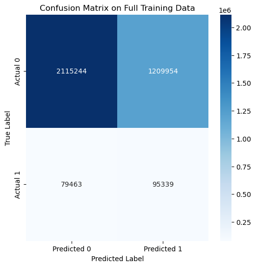

```python
# Predict on the full training data
y_pred_train = final_pipeline.predict(X_train_no_probs)
y_pred_proba = final_pipeline.predict_proba(X_train_no_probs)

# Print accuracy score on the full training data
accuracy_train = accuracy_score(y_train, y_pred_train)
print(f"\nAccuracy Score on Full Training Data: {accuracy_train * 100:.2f}%")



threshold =  0.5
roc_auc_curve(y_pred_proba[:,1], y_train, title = "\nReceiver Operating Characteristic (ROC) Curve\nTest Data", threshold = threshold)


# Print confusion matrix
cm = confusion_matrix(y_train, y_pred_train)
plt.figure(figsize=(6, 6))
sns.heatmap(cm, annot=True, fmt="d", cmap="Blues", xticklabels=['Predicted 0', 'Predicted 1'],
            yticklabels=['Actual 0', 'Actual 1'])
plt.xlabel('Predicted Label')
plt.ylabel('True Label')
plt.title('Confusion Matrix on Full Training Data')
plt.show()
```

```python
print(classification_report(y_train, y_pred_train))
```

```
              precision    recall  f1-score   support

           0       0.96      0.64      0.77   3325198
           1       0.07      0.55      0.13    174802

    accuracy                           0.63   3500000
   macro avg       0.52      0.59      0.45   3500000
weighted avg       0.92      0.63      0.73   3500000
```

**Evaluate Optimal Regularized Logistic Regression Model on Test Dataset**

```
Accuracy Score on Test Data: 63.11%
```

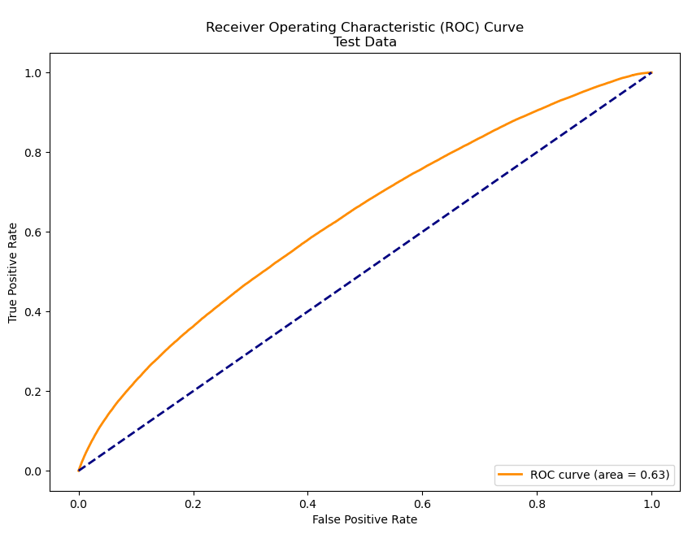

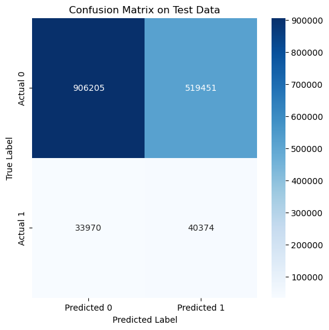

```python
# Predict on the test data
y_pred_test = final_pipeline.predict(X_test_no_probs)
y_pred_proba = final_pipeline.predict_proba(X_test_no_probs)


# Print accuracy score on test data
accuracy_test = accuracy_score(y_test, y_pred_test)
print(f"\nAccuracy Score on Test Data: {accuracy_test * 100:.2f}%")


threshold =  0.5
roc_auc_curve(y_pred_proba[:,1], y_test, title = "\nReceiver Operating Characteristic (ROC) Curve\nTest Data", threshold = threshold)


# Print confusion matrix
cm = confusion_matrix(y_test, y_pred_test)
plt.figure(figsize=(6, 6))
sns.heatmap(cm, annot=True, fmt="d", cmap="Blues", xticklabels=['Predicted 0', 'Predicted 1'],
            yticklabels=['Actual 0', 'Actual 1'])
plt.xlabel('Predicted Label')
plt.ylabel('True Label')
plt.title('Confusion Matrix on Test Data')
plt.show()
```

```python
print(classification_report(y_test, y_pred_test))
```

```
              precision    recall  f1-score   support

           0       0.96      0.64      0.77   1425656
           1       0.07      0.54      0.13     74344

    accuracy                           0.63   1500000
   macro avg       0.52      0.59      0.45   1500000
weighted avg       0.92      0.63      0.73   1500000
```

Similar to what we had already seen while tuning the the regularization parameter, upon comparing the model's performance on the training and test datasets, we observe a robust and predictive model, as evidenced by nearly identical accuracy scores on both datasets (around 63%). Additionally, the model exhibits a commendable ability to distinguish between users who click on the recommended card and those who do not. This is evident in the both the train data and test data recall, striking a good balance between sensitivity (54%) and specificity (64%), specially considering that the dataset is quite unbalanced.

**Analysis of Features**

Next, we focus on analyzing the features and their associated coefficients. Due to the considerable dimensionality of the features, our initial step involves identifying statistically significant features using the criterion: if the p-value is less than or equal to 0.05, the feature is deemed statistically significant. Subsequently, we assess the magnitude of each feature's coefficient to derive meaningful insights from the results. In order to accomplish this, we must resort to the functions provided by statsmodels logistic regression since the logistic regression model in scikit-learn does not generate p-values or confidence intervals, which hinders the ability to conduct statistical inference.

```python
feature_names = X_train_no_probs.columns
sk_coefficients = logistic_regression_model.coef_[0]
sk_coefficients = dict(zip(feature_names, sk_coefficients))

# Extract X_train with the preprocessor
X_train_processed = final_pipeline.named_steps['preprocessor'].transform(X_train_no_probs)

# Fit logistic regression with statsmodels for p-values
logit_model = sm.Logit(y_train, sm.add_constant(X_train_processed))
result = logit_model.fit()


# Identify significant coefficients and their confidence interval with p-values less than 0.05
significant_features = {}
for idx, p_value in enumerate(result.pvalues):
    if p_value < 0.05:
        if idx !=0:
            feature_name =  feature_names[idx-1]
            significant_features[feature_name]= [np.exp(sk_coefficients[feature_name]),
                                                 np.exp(result.params[idx]),
                                                 np.exp(result.conf_int()[0][idx]),
                                                 np.exp(result.conf_int()[1][idx])]
```

```
Optimization terminated successfully.
         Current function value: 0.193071
         Iterations 9
```

```python
significant_features_df = pd.DataFrame.from_dict(significant_features, orient='index',
                                                 columns=['SK Odd Ratio', 'SM Odd Ratio' ,
                                                          'CI Lower (2.5%)', 'CI Upper (97.5%)'])


significant_features_df.head(5)
```

|  | SK Odd Ratio | SM Odd Ratio | CI Lower (2.5%) | CI Upper (97.5%) |
| --- | --- | --- | --- | --- |
| type_2.0 | 1.018523 | 1.016079 | 1.011127 | 1.021055 |
| user_gender_male | 1.011598 | 1.011729 | 1.008388 | 1.015082 |
| user_gender_unknown | 1.009840 | 1.008119 | 1.004976 | 1.011272 |
| creator_gender_male | 1.009670 | 1.008208 | 1.005170 | 1.011255 |
| creator_gender_unknown | 1.068863 | 1.064967 | 1.060581 | 1.069371 |

*Numerical & Binary Variables*

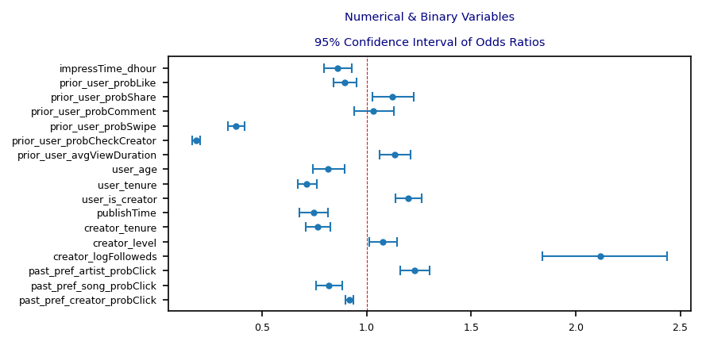

```python
numerical_significant_features_df = significant_features_df[significant_features_df.index.isin(numerical_cols)]

fig, ax = plt.subplots(nrows=1, sharex=True, sharey=True, figsize=(6, 3), dpi=150)
for idx, row in numerical_significant_features_df.iloc[::-1].iterrows():
    ci = [[ row[ 'SM Odd Ratio' ] - row[::-1][ 'CI Lower (2.5%)']], [row['CI Upper (97.5%)'] - row['SM Odd Ratio']]]
    plt.errorbar(x=[row['SK Odd Ratio']], y=[row.name], xerr=ci,
            ecolor='tab:blue', capsize=3, linestyle='None', linewidth=1, marker="o",
                     markersize=3, mfc="tab:blue", mec="tab:blue")
plt.axvline(x=1, linewidth=0.5, linestyle='--', color='red')
plt.tick_params(axis='both', which='major', labelsize=6)
plt.title('Numerical & Binary Variables\n\n95% Confidence Interval of Odds Ratios', fontsize=7, color =  "navy")
plt.tight_layout()
plt.show()
```

*Categorical Variables*

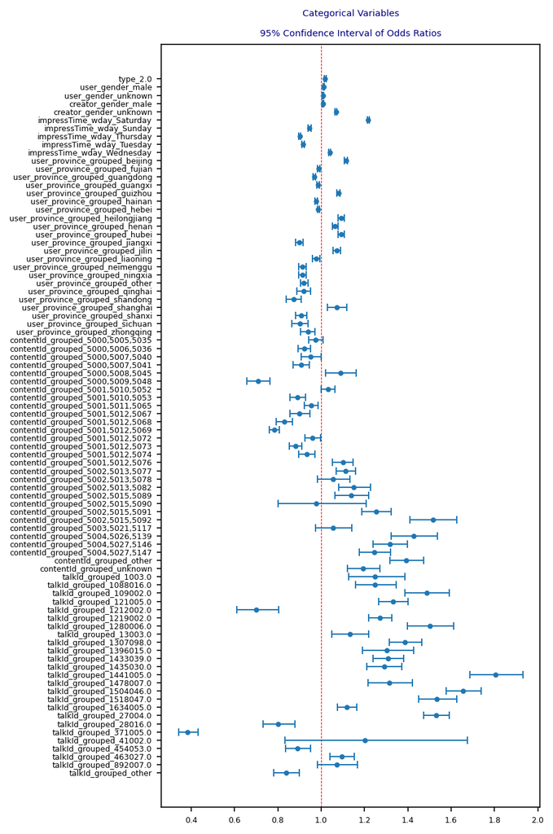

```python
categorical_significant_features_df = significant_features_df[~significant_features_df.index.isin(numerical_cols)]

fig, ax = plt.subplots(nrows=1, sharex=True, sharey=True, figsize=(6, 9), dpi=150)
for idx, row in categorical_significant_features_df.iloc[::-1].iterrows():
    ci = [[ row[ 'SM Odd Ratio' ] - row[::-1][ 'CI Lower (2.5%)']], [row['CI Upper (97.5%)'] - row['SM Odd Ratio']]]
    plt.errorbar(x=[row['SK Odd Ratio']], y=[row.name], xerr=ci,
            ecolor='tab:blue', capsize=3, linestyle='None', linewidth=1, marker="o",
                     markersize=3, mfc="tab:blue", mec="tab:blue")
plt.axvline(x=1, linewidth=0.5, linestyle='--', color='red')
plt.tick_params(axis='both', which='major', labelsize=6)
plt.title('Categorical Variables\n\n95% Confidence Interval of Odds Ratios', fontsize=7, color =  "navy")
plt.tight_layout()
plt.show()
```

### Decision Tree

Next we will investigate tree based models for this problem. Having trained a classifier with a Neural network model, our goal now is to train more interpretable models, to validate our intuition about the behaviour of the users and gain further insights into the possible next steps in the development of this product. Furthermore, we will have the opportunity to compare how the most import features compare with the Logistic regression model.

As with the previous models, the hyperparameter tuning was done in a separate notebook due to computational constraints. It's also worth noting that for the same reason, we had to make concessions in the methods we used. This means it is likley that with access to a cloud based enviroment where we could scale our computational capacity vertically we would be able to achieve higher performance with our model by expanding the search domain.

[figure not shown]

```python
# Use best parameters from the hyper-parameter tuning notebook
best_params = {'min_samples_split': 200, 'max_depth': 5, 'criterion': 'entropy'}

# Train the decision tree model using the class_weight balances method
tree = DecisionTreeClassifier(random_state=0, max_depth = best_params['max_depth'],
                              criterion=best_params['criterion'], min_samples_split = best_params['min_samples_split'],
                              class_weight='balanced')

# Fit decision tree on the training data
tree.fit(X_train_no_probs, y_train)
```

After training the model, we analyse the features it ended upda using. It turns out that there are similarities with what was observed for the logistic regression model, but also there are many features that had an important coefficient in that model and did not make it to the decision tree. Of course we understand one of the limitations of the decision tree models is that it can leave out important features due to the decision bias of the main features. That is why we will also explore a random forest approach.

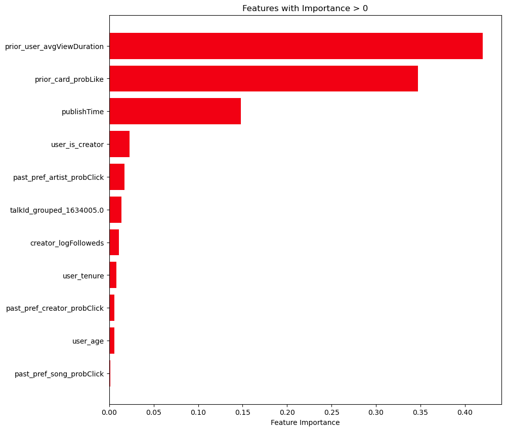

```python
# Get feature importances
dt_feature_importances = tree.feature_importances_

# Create a dictionary to associate feature names with importances
dt_feature_importance_dict = dict(zip(feature_names, dt_feature_importances))

# Round feature importances to 3 decimal places
rounded_importances = {feature: round(importance, 3) for feature, importance in dt_feature_importance_dict.items()}

# Get features with importance greater than 0
positive_importances = {feature: importance for feature, importance in rounded_importances.items() if importance > 0}

# Sort positive importances
sorted_positive_importances = sorted(positive_importances.items(), key=lambda x: x[1], reverse=False)

# Plot the positive feature importances
plt.figure(figsize=(10, 10))
plt.barh(range(len(sorted_positive_importances)), [importance for _, importance in sorted_positive_importances],
         align='center', color='#F20013')
plt.yticks(range(len(sorted_positive_importances)), [feature for feature, _ in sorted_positive_importances])
plt.xlabel('Feature Importance')
plt.title('Features with Importance > 0')
plt.show()
```

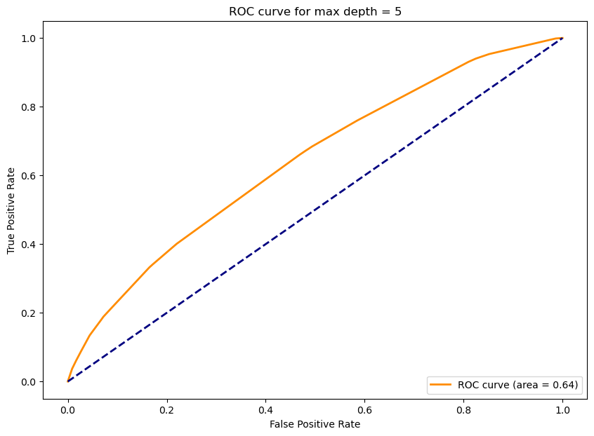

```python
# Calculate the y_scores
y_pred_prob = tree.predict_proba(X_test_no_probs)[:, 1]

# Calculate ROC curve
roc_auc_curve(y_pred_prob, f"ROC curve for max depth = {best_params['max_depth']}")
```

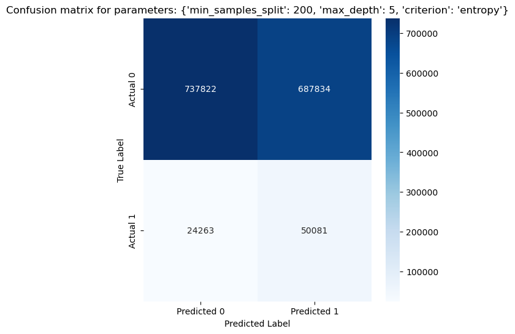

```python
cm_print(X_test_no_probs, y_test, tree, f"Confusion matrix for parameters: {best_params}")
```

```python
print(classification_report(y_test, tree.predict(X_test_no_probs)))
```

```
              precision    recall  f1-score   support

           0       0.97      0.52      0.67   1425656
           1       0.07      0.67      0.12     74344

    accuracy                           0.53   1500000
   macro avg       0.52      0.60      0.40   1500000
weighted avg       0.92      0.53      0.65   1500000
```

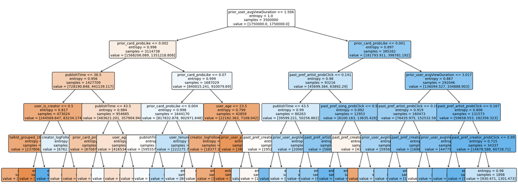

```python
# Plot the tree
plt.figure(figsize=(25, 10))
plot_tree(tree, feature_names=feature_names, filled=True, rounded=True, fontsize=10)
plt.show()
```

In order to have a better undersanting of the difference in feature importances between the two models, we explore the plot below. All of the features were plotted, which makes it hard to interpret. Therefore, we will filter the features down.

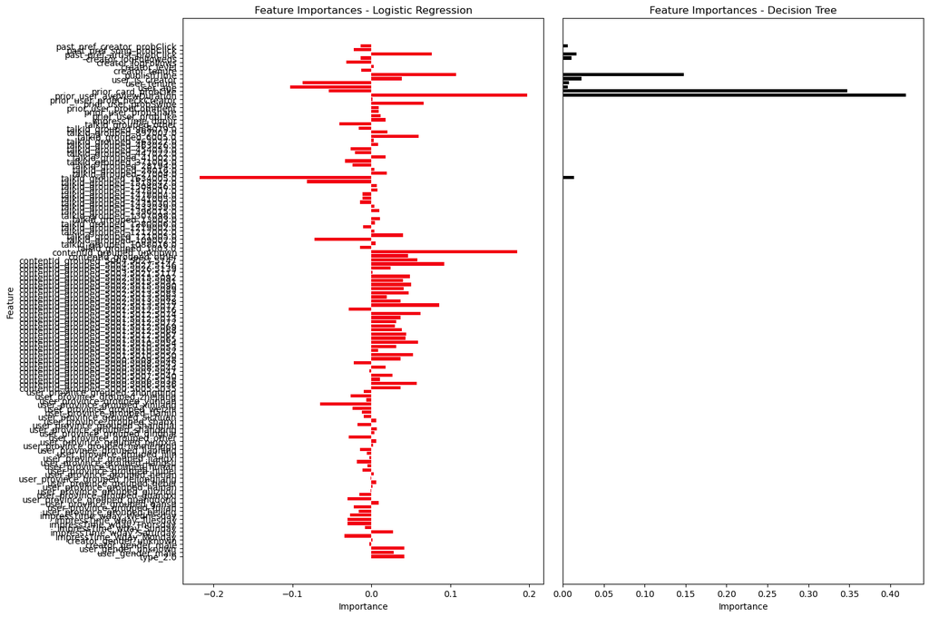

```python
# Plot feature importances for Logistic Regression
plt.figure(figsize=(15, 10))

# Plot feature importances for Logistic Regression
plt.subplot(1, 2, 1)
bar_left = plt.barh(range(len(sk_coefficients)), list(sk_coefficients.values()), color='#F20013', label='Logistic Regression')
plt.xlabel('Importance')
plt.ylabel('Feature')
plt.title('Feature Importances - Logistic Regression')
plt.yticks(range(len(feature_names)), feature_names)  # Set y-axis ticks only once on the left

# Plot feature importances for Decision Tree
plt.subplot(1, 2, 2)
bar_right = plt.barh(range(len(feature_importances)), dt_feature_importances, color='black', label='Decision Tree')
plt.xlabel('Importance')
plt.title('Feature Importances - Decision Tree')
plt.yticks([])  # No y-axis ticks on the right

plt.tight_layout()
plt.show()
```

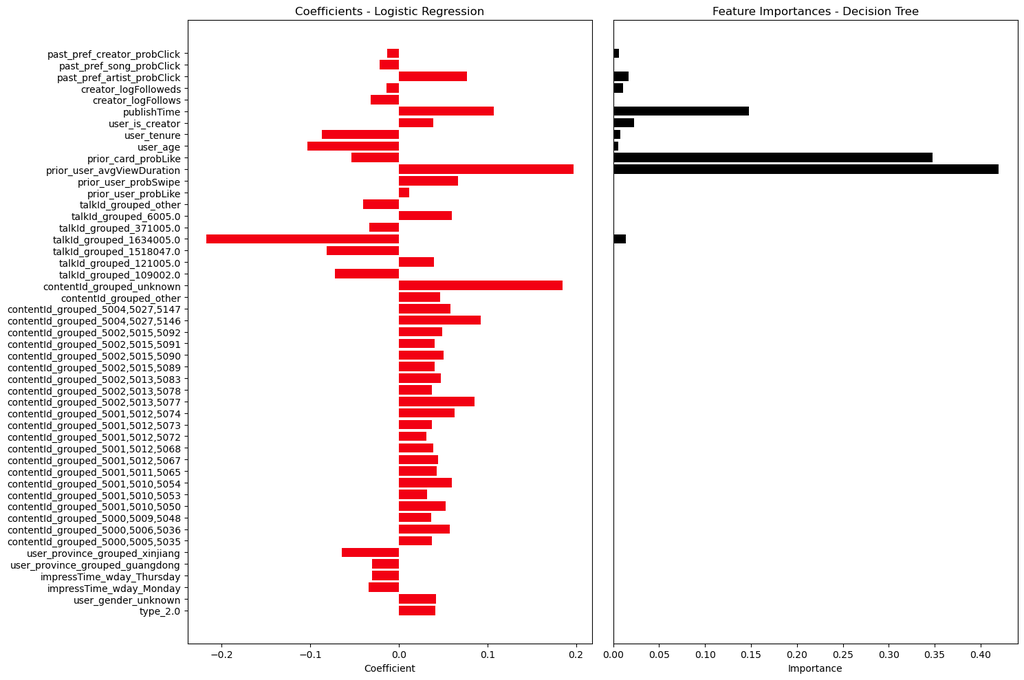

```python
# List of features
features = list(feature_importance_dict.keys())
logit_coefs = list(sk_coefficients.values())
decision_tree_importances = dt_feature_importances

# Create DataFrame
importances_df = pd.DataFrame({
    'feature': features,
    'logit_coefs': logit_coefs,
    'dt_importances': decision_tree_importances
})

thresh_min = -0.03
thresh_max = 0.03

df = importances_df[(importances_df['logit_coefs']>=thresh_max) | (importances_df['logit_coefs']<=thresh_min) | (importances_df['dt_importances']>0)]

# Plot feature importances for Logistic Regression
plt.figure(figsize=(15, 10))

# Plot feature importances for Logistic Regression
plt.subplot(1, 2, 1)
bar_left = plt.barh(range(len(df)), df['logit_coefs'], color='#F20013', label='Logistic Regression')
plt.xlabel('Coefficient')
plt.title('Coefficients - Logistic Regression')
plt.yticks(range(len(df)), df['feature'])  # Set y-axis ticks only once on the left

# Plot feature importances for Decision Tree
plt.subplot(1, 2, 2)
bar_right = plt.barh(range(len(df)), df['dt_importances'], color='black', label='Decision Tree')
plt.xlabel('Importance')
plt.title('Feature Importances - Decision Tree')
plt.yticks([])  # No y-axis ticks on the right

plt.tight_layout()
plt.show()
```

On the plot on the left, any deviation from the center (towards negative or positive numbers) indicate that the coefficient is relevant. So we see some notable deviations. This is further explored in the final report and possible explanations are provided there.

### Random Forest

The final model we will test is the random forest. The goal here is to target some of weaknesses of the decition tree while keeping the explainability of the decision tree based models. We import the best hyper-parameters from the tuning notebok and fit the model using the class_weight = 'balanced' again.

```python
best_params = {'max_depth': 5, 'n_estimators': 50}

rf = RandomForestClassifier(random_state=0, max_depth = best_params['max_depth'],
                              n_estimators=best_params['n_estimators'],class_weight='balanced')

# Fit decision rf on the training data
rf.fit(X_train_no_probs, y_train)
```

```
RandomForestClassifier(class_weight='balanced', max_depth=5, n_estimators=50,
                       random_state=0)
```

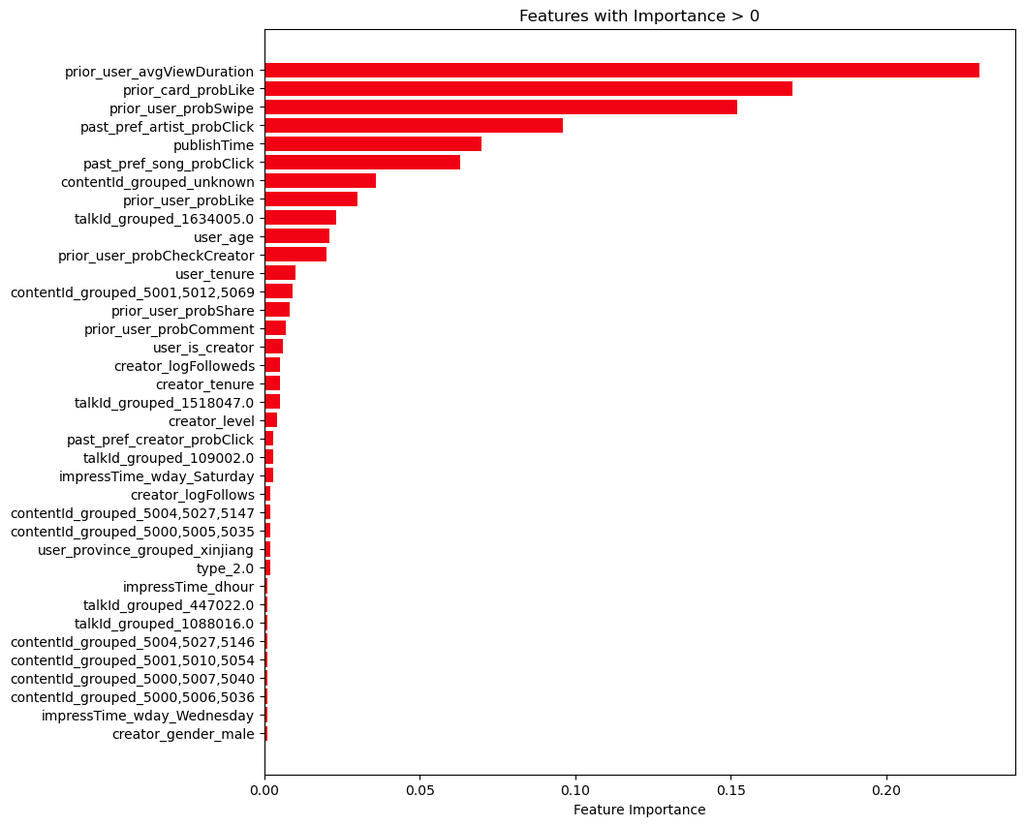

```python
# Get feature importances
rf_feature_importances = rf.feature_importances_

# Create a dictionary to associate feature names with importances
rf_feature_importance_dict = dict(zip(feature_names, rf_feature_importances))

# Round feature importances to 3 decimal places
rounded_importances = {feature: round(importance, 3) for feature, importance in rf_feature_importance_dict.items()}

# Get features with importance greater than 0
positive_importances = {feature: importance for feature, importance in rounded_importances.items() if importance > 0}

# Sort positive importances
sorted_positive_importances = sorted(positive_importances.items(), key=lambda x: x[1], reverse=False)

# Plot the positive feature importances
plt.figure(figsize=(10, 10))
plt.barh(range(len(sorted_positive_importances)), [importance for _, importance in sorted_positive_importances],
         align='center', color='#F20013')
plt.yticks(range(len(sorted_positive_importances)), [feature for feature, _ in sorted_positive_importances])
plt.xlabel('Feature Importance')
plt.title('Features with Importance > 0')
plt.show()
```

As we would expect, the Random Forest model has more features being considered. The dirstribution is very similar to that of the decision tree. We will compare the features from the three models in the following cells. Looking at the AUC and accuracy of this model, it is the best performing model so far

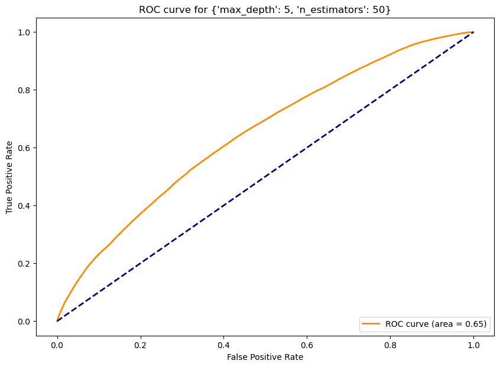

```python
# Calculate the y_scores
y_pred_prob = rf.predict_proba(X_test_no_probs)[:, 1]

# Calculate ROC curve
roc_auc_curve(y_pred_prob, f"ROC curve for {best_params}")
```

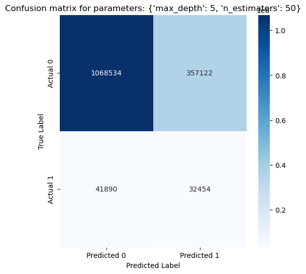

```python
cm_print(X_test_no_probs, y_test, rf, f"Confusion matrix for parameters: {best_params}")
```

```python
print(classification_report(y_test, rf.predict(X_test_no_probs)))
```

```
              precision    recall  f1-score   support

           0       0.96      0.75      0.84   1425656
           1       0.08      0.44      0.14     74344

    accuracy                           0.73   1500000
   macro avg       0.52      0.59      0.49   1500000
weighted avg       0.92      0.73      0.81   1500000
```

However, inspecting the classification report it shows us that the improved accuracy and AUC comes at the cost of recall for the class 1 and improving it for class 0 (i.e: no click). With this in mind, we will explore in the final report which model to use in the end for the recommendation system based on the performance against the baseline of precision at 6 cards.

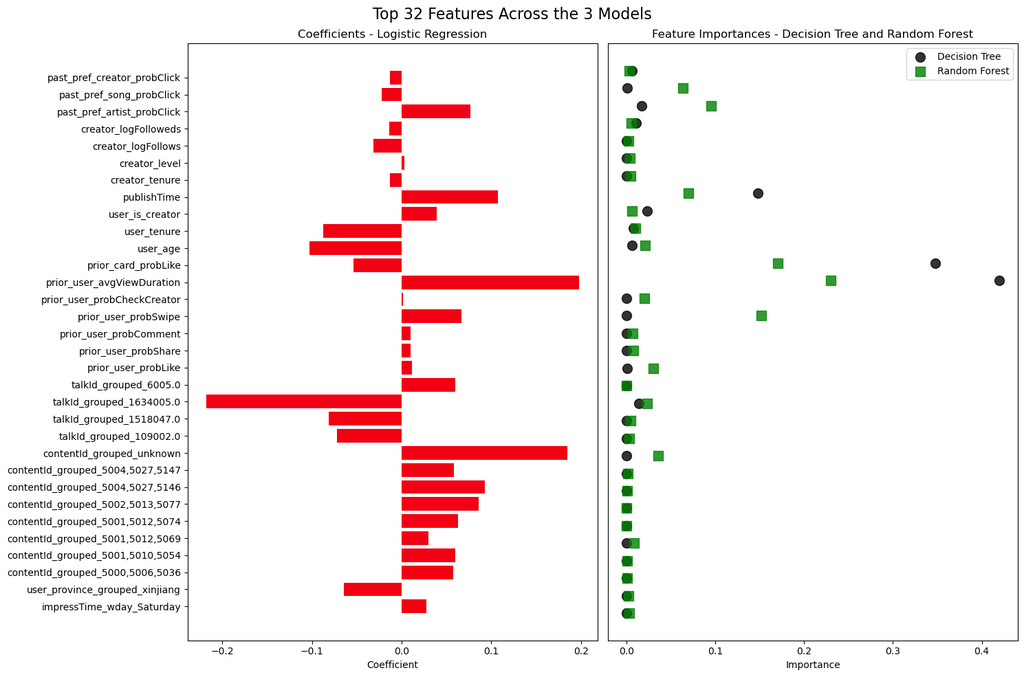

```python
# List of features
features = list(feature_importance_dict.keys())
logit_coefs = list(sk_coefficients.values())
decision_tree_importances = dt_feature_importances
random_forest_importances = rf_feature_importances

# Create DataFrame
importances_df = pd.DataFrame({
    'feature': features,
    'logit_coefs': logit_coefs,
    'dt_importances': decision_tree_importances,
    'rf_importances': random_forest_importances
})

thresh_min = -0.057
thresh_max = 0.057

df = importances_df[(importances_df['logit_coefs'] >= thresh_max) | (importances_df['logit_coefs'] <= thresh_min)
                    | (importances_df['dt_importances'] > 0) | (importances_df['rf_importances'] > 0.002)]

# Plot feature importances for Logistic Regression
plt.figure(figsize=(15, 10))

# Plot feature importances for Logistic Regression
plt.subplot(1, 2, 1)
bar_left = plt.barh(range(len(df)), df['logit_coefs'], color='#F20013', label='Logistic Regression')
plt.xlabel('Coefficient')
plt.title('Coefficients - Logistic Regression')
plt.yticks(range(len(df)), df['feature'])  # Set y-axis ticks only once on the left

# Plot feature importances for Decision Tree and Random Forest
plt.subplot(1, 2, 2)
plt.scatter(df['dt_importances'], range(len(df)), color='black', label='Decision Tree', s=100, alpha=0.8)
plt.scatter(df['rf_importances'], range(len(df)), color='green', label='Random Forest',marker='s', s=100, alpha=0.8)
plt.xlabel('Importance')
plt.title('Feature Importances - Decision Tree and Random Forest')
plt.yticks([])  # No y-axis ticks

plt.suptitle('Top 32 Features Across the 3 Models', fontsize=16)  # Add a title to the entire figure
plt.legend()
plt.tight_layout()
plt.show()
```

Finally, we explore the feature importances for the three models. We will delve into the consensual features, and use it to reinforce our recommendations. These can also be use for future product, marketing strategies and on-boarding strategical decisions. The features that were deemed important by the logistic regression model and not the tree based models also need to be investigated.